# Survival Analysis

Peter Ralph

7 January 2020 – Advanced Biological Statistics

# Overview

## “Survival” analysis:

We are interested in *how long until* some particular thing happens, and *how this depends* on some covariates.

*Example:* how years until death depends on cancer grade at diagnosis and drug treatment.

*Example:* how day of first budburst depends on species and local temperature.

## Surivival data

*Ex:* For each patient, date of diagnosis and cancer grade; date of death or last follow-up.

*Ex:* For each plant, species, date of first budburst or last survey.

Both examples are **right censored**: for some subjects, we don’t know how the actual time, only a lower bound on it.

**Key assumption:** any censoring is *noninformative*,

i.e., our data collection does not depend on the status of the subjects.

Examples of *informative* censoring: patient dropout due to worsening symptoms.

## What do we want to know?

The *survival curve:*

$$\begin{aligned}
S(t)
&=
\P\{\text{still 'alive' after $t$ time units}\} ,
\end{aligned}$$

*Note:* this is always *decreasing*.

and the *hazard rate:*

$$\begin{aligned}
h(t)
&=
\text{(mean number of 'deaths' per still-alive subject,}
\\ &\qquad \text{per unit time at $t$)} ,
\end{aligned}$$

which is

$$\begin{aligned}
h(t) = - \frac{d}{dt} \log S(t) .
\end{aligned}$$

## Nonparametric versus parametric?

We’ll look at some methods across the nonparametric-to-parametric continuum.

- *Nonparametric:* fewer assumptions.
- *Parametric:* fits a full, generative probability model.

Interpret the differences between these *survival curves*:

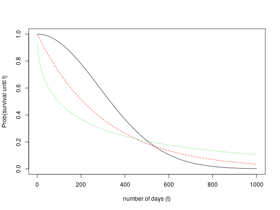

## More information:

- A [series](https://www.ncbi.nlm.nih.gov/pmc/articles/PMC2394262/) [of](https://www.ncbi.nlm.nih.gov/pmc/articles/PMC2394368/) [nice](https://www.ncbi.nlm.nih.gov/pmc/articles/PMC2376927/) [reviews](https://www.ncbi.nlm.nih.gov/pmc/articles/PMC2394469/), by Clark, Bradburn, Love, and Altman.
- A [tutorial](https://www.emilyzabor.com/tutorials/survival_analysis_in_r_tutorial.html) by Emily Zabor.

the [CRAN task view](https://cran.r-project.org/web/views/Survival.html)

# Datasets:

## [NCCTG Lung Cancer Data](https://www.ncbi.nlm.nih.gov/pubmed/8120560)

```r
library(survival)
data(lung)
## help(lung)
```

```
NCCTG Lung Cancer Data

Description:

     Survival in patients with advanced lung cancer from the North
     Central Cancer Treatment Group.  Performance scores rate how well
     the patient can perform usual daily activities.

Usage:

     lung
     cancer

Format:

       inst:       Institution code
       time:       Survival time in days
       status:     censoring status 1=censored, 2=dead
       age:        Age in years
       sex:        Male=1 Female=2
       ph.ecog:    ECOG performance score as rated by the physician.
                   0=asymptomatic, 1= symptomatic but completely ambulatory, 2= in bed
                   <50% of the day, 3= in bed > 50% of the day but not bedbound, 4 =
                   bedbound
       ph.karno:   Karnofsky performance score (bad=0-good=100) rated by physician
       pat.karno:  Karnofsky performance score as rated by patient
       meal.cal:   Calories consumed at meals
       wt.loss:    Weight loss in last six months

Note:

     The use of 1/2 for alive/dead instead of the usual 0/1 is a
     historical footnote.  For data contained on punch cards, IBM 360
     Fortran treated blank as a zero, which led to a policy within the
     section of Biostatistics to never use "0" as a data value since
     one could not distinguish it from a missing value.  The policy
     became a habit, as is often the case; and the 1/2 coding endured
     long beyond the demise of punch cards and Fortran.

Source:

     Terry Therneau

References:

     Loprinzi CL. Laurie JA. Wieand HS. Krook JE. Novotny PJ.  Kugler
     JW. Bartel J. Law M. Bateman M. Klatt NE. et al.  Prospective
     evaluation of prognostic variables from patient-completed
     questionnaires. North Central Cancer Treatment Group.  Journal of
     Clinical Oncology. 12(3):601-7, 1994.
```

## Simulation: Constant hazard rate

Time until arrival of a high-energy neutrino in each of many detectors:

```r
nrate <- 1 / 365
study_time <- 4 * 365
nobs <- 228
neutrinos <- data.frame(
        detector_id = 1:nobs,
        time = rexp(nobs, rate=nrate))
neutrinos$status <- (neutrinos$time < study_time)
neutrinos$time <- pmin(study_time, neutrinos$time)
```

## Simulation: Increasing hazard rate

Time until failure of lightbulbs, that wear out as time goes on:

```r
lmean <- 2 * 365
bulbs <- data.frame(
        bulb_id = 1:nobs,
        time = abs(rnorm(nobs, sd=lmean)))
bulbs$status <- (bulbs$time < study_time)
bulbs$time <- pmin(study_time, bulbs$time)
```

# Kaplan-Meier curves

## Estimating probabilities

Suppose that:

- we start with 100 chickens
- in the first year, 25 of them die
- in the second year, 25 of them die
- at the end of the second year, we give 25 of the survivors away
- in the third year, 15 of them die

**Questions:**

- What percent survived each year? (of those that began that year alive)
- Find the probability of surviving to 1, 2, 3, and 4 years,
- and draw the survival curve.
- Find a confidence interval for each probability.

The **Kaplan-Meier survival curve** is a purely empirical, nonparametric estimate of survival probability:

- one interval per unique event time
- estimated probability of surviving an interval is the proportion that did
- and so the probability of surviving until $t$ is the product of all the survival probabilities before $t$

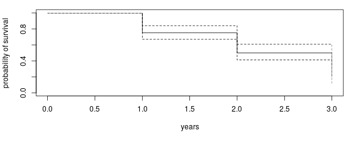

```r
plot(Surv(time=rep(1:3, times=c(25, 50, 25)),
          event=c(rep(2, 25), rep(2, 25), rep(1, 25), rep(2, 15), rep(1, 10))), xlab="years", ylab="probability of survival", ylim=c(0,1))
```

## Neutrinos:

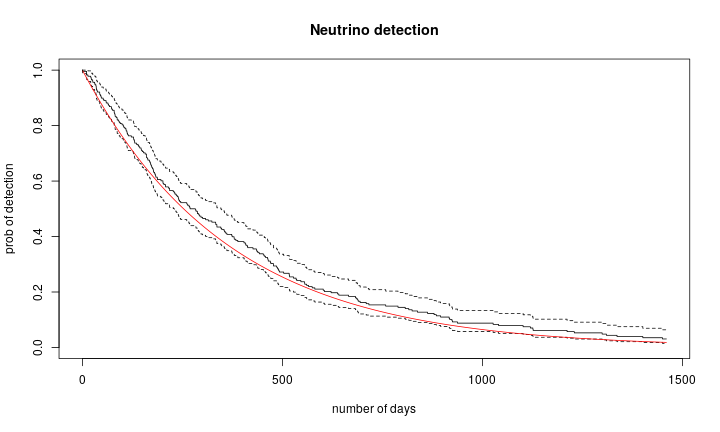

```r
neutrino_sf <- survfit(Surv(time, status) ~ 1, data=neutrinos)
plot(neutrino_sf, xlab='number of days', ylab='prob of detection', main="Neutrino detection")
lines(1:study_time, pexp(1:study_time, rate=nrate, lower.tail=FALSE), col='red')
```

## Light bulbs:

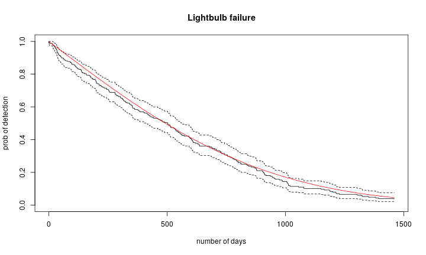

```r
bulb_sf <- survfit(Surv(time, status) ~ 1, data=bulbs)
plot(bulb_sf, xlab='number of days', ylab='prob of detection', main="Lightbulb failure")
lines(1:study_time, 2 * pnorm(1:study_time, sd=lmean, lower.tail=FALSE), col='red')
```

## Compared

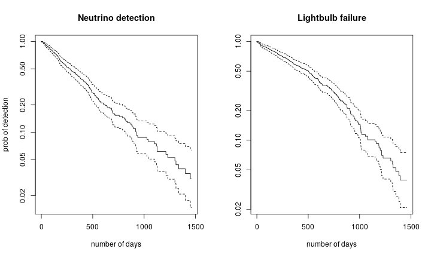

```r
layout(t(1:2))
plot(neutrino_sf, xlab='number of days', ylab='prob of detection', main="Neutrino detection", log='y')
plot(bulb_sf, xlab='number of days', main="Lightbulb failure", log='y')
```

## Lung cancer survival:

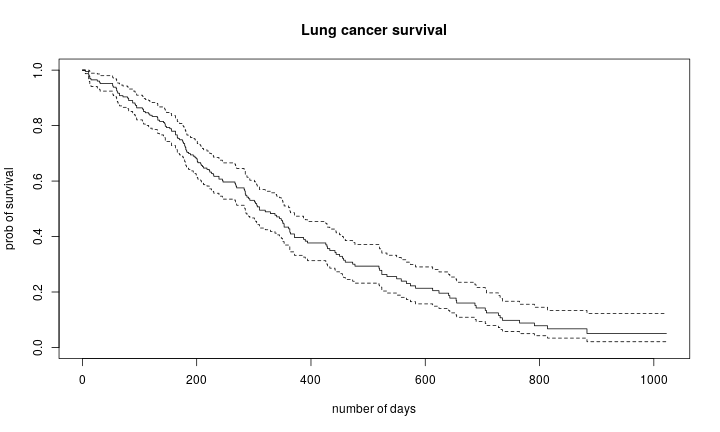

```r
lung_sf <- survfit(Surv(time, status) ~ 1, data=lung)
plot(lung_sf, conf.int=TRUE, xlab='number of days', ylab='prob of survival', main="Lung cancer survival")
```

## Hazard rate is slope of survival on a log scale:

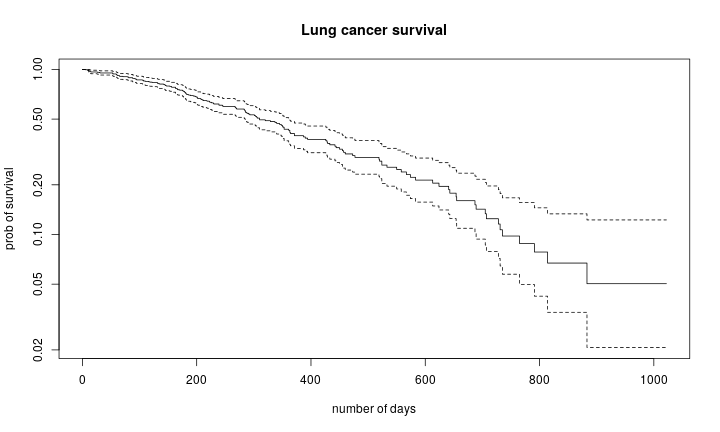

## Survival, by sex:

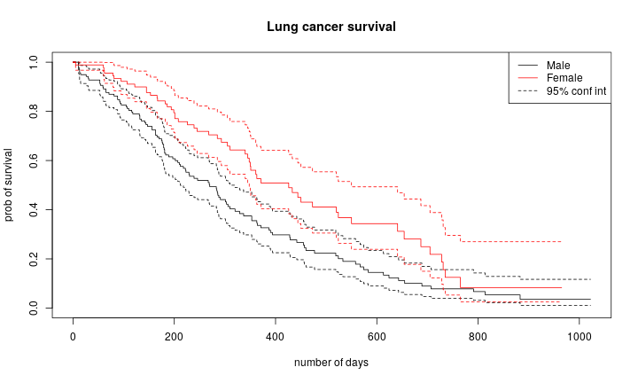

```r
lung_sf_bysex <- survfit(Surv(time, status) ~ sex, data=lung)
plot(lung_sf_bysex, col=1:2, conf.int=TRUE, xlab='number of days', ylab='prob of survival', main="Lung cancer survival")
legend("topright", lty=c(1,1,2), col=c(1,2,1), legend=c("Male", "Female", "95% conf int"))
```

# Interpretation interlude:

Survival analysis is used to estimate the chance of surviving a given type of cancer for a given number of years.

**Question:** How accurate is that?

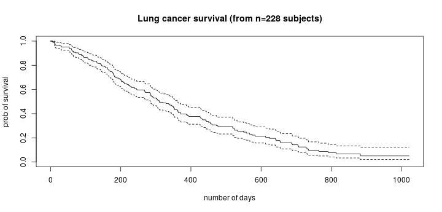

# Cox’s proportional hazards

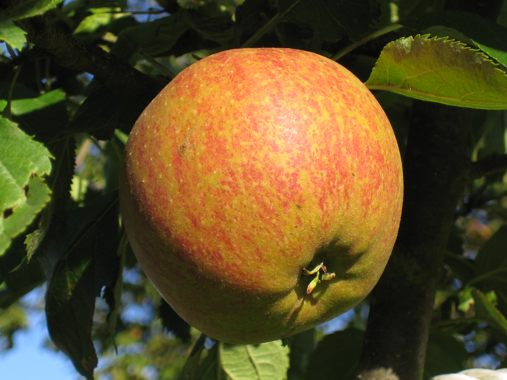

Cox’s orange pippin (credit: Wikimedia)

## Proportional Hazards

*Goal:* understand how covariates affect survival time.

*Idea:* modify a nonparametric hazard rate by a linear predictor:
$$h(t) = h_0(t) e^{\beta x} .$$

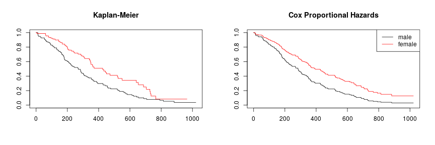

## Covariates

How does survival probability depend on the covariates?

```
age:        Age in years
sex:        Male=1 Female=2
ph.ecog:    ECOG performance score as rated by the physician.
            (good=0-bad=4)
ph.karno:   Karnofsky performance score (bad=0-good=100) rated by physician
pat.karno:  Karnofsky performance score as rated by patient
meal.cal:   Calories consumed at meals
wt.loss:    Weight loss in last six months
```

## Covariates

How does survival probability depend on the covariates?

```
age:        Age in years
sex:        Male=1 Female=2
ph.ecog:    ECOG performance score as rated by the physician.
            (good=0-bad=4)
ph.karno:   Karnofsky performance score (bad=0-good=100) rated by physician
pat.karno:  Karnofsky performance score as rated by patient
meal.cal:   Calories consumed at meals
wt.loss:    Weight loss in last six months
```

$$\begin{aligned}
h(t) &= \text{(baseline hazard rate at $t$)} \\
y_i &= \beta_0 + \sum_j \beta_j x_{ij} \\
h_i(t) &= \text{(hazard rate for $i$ at $t$)} \\
&= h(t) \times \exp\left( y_i \right) \\
S_i(t) &= \P\left\{\text{survival of $i$ until $t$}\right\} \\
&= \exp\left( - \int_0^t h_i(s) ds \right) .
\end{aligned}$$

## Fitting a Cox model

```r
fullcox <- coxph(Surv(time, status)
             ~ age + sex + ph.ecog + ph.karno + pat.karno
             + meal.cal + wt.loss,
         data = lung)
summary(fullcox)
```

```
## Call:
## coxph(formula = Surv(time, status) ~ age + sex + ph.ecog + ph.karno +
##     pat.karno + meal.cal + wt.loss, data = lung)
##
##   n= 168, number of events= 121
##    (60 observations deleted due to missingness)
##
##                 coef  exp(coef)   se(coef)      z Pr(>|z|)
## age        1.065e-02  1.011e+00  1.161e-02  0.917  0.35906
## sex       -5.509e-01  5.765e-01  2.008e-01 -2.743  0.00609 **
## ph.ecog    7.342e-01  2.084e+00  2.233e-01  3.288  0.00101 **
## ph.karno   2.246e-02  1.023e+00  1.124e-02  1.998  0.04574 *
## pat.karno -1.242e-02  9.877e-01  8.054e-03 -1.542  0.12316
## meal.cal   3.329e-05  1.000e+00  2.595e-04  0.128  0.89791
## wt.loss   -1.433e-02  9.858e-01  7.771e-03 -1.844  0.06518 .
## ---
## Signif. codes:  0 '***' 0.001 '**' 0.01 '*' 0.05 '.' 0.1 ' ' 1
##
##           exp(coef) exp(-coef) lower .95 upper .95
## age          1.0107     0.9894    0.9880    1.0340
## sex          0.5765     1.7347    0.3889    0.8545
## ph.ecog      2.0838     0.4799    1.3452    3.2277
## ph.karno     1.0227     0.9778    1.0004    1.0455
## pat.karno    0.9877     1.0125    0.9722    1.0034
## meal.cal     1.0000     1.0000    0.9995    1.0005
## wt.loss      0.9858     1.0144    0.9709    1.0009
##
## Concordance= 0.651  (se = 0.029 )
## Likelihood ratio test= 28.33  on 7 df,   p=2e-04
## Wald test            = 27.58  on 7 df,   p=3e-04
## Score (logrank) test = 28.41  on 7 df,   p=2e-04
```

## Model comparison

```r
subcox <- coxph(Surv(time, status) ~ sex + ph.ecog, data = lung, subset=rowSums(is.na(lung[,2:10]))==0)
anova(fullcox, subcox)
```

```
## Analysis of Deviance Table
##  Cox model: response is  Surv(time, status)
##  Model 1: ~ age + sex + ph.ecog + ph.karno + pat.karno + meal.cal + wt.loss
##  Model 2: ~ sex + ph.ecog
##    loglik  Chisq Df P(>|Chi|)
## 1 -498.75
## 2 -503.14 8.7792  5    0.1182
```

## Predictions

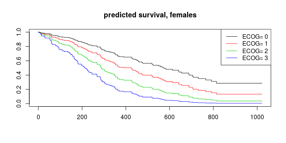

```r
subcox_pred <- survfit(subcox, newdata=expand.grid(ph.ecog=0:3, sex=2))
plot(subcox_pred, lty=1, col=1:4, main='predicted survival, females')
legend("topright", lty=1, col=1:4, legend=paste("ECOG=", 0:3))
```

## In class: interpretation

- physicians evaluation matters
  - lowest to highest ECOG: 20% to 80% survival at one year
- sex and ECOG have large, significant effects
  - males have lower survival
  - 50% lower survival rate for males
- higher weight loss => higher survival rate, strangely
  - but not significant
- age, caloric intake, patient assessment not significant
  - specifics?
- institutional differences
  - specifics?

# Stochastic minute: Weibull

## The Weibull distribution

If $T$ has a [Weibull distribution](https://en.wikipedia.org/wiki/Weibull_distribution), with scale $\lambda$ and shape $k$, then

- $T \ge 0$
- $\P\{ T > t \} = \exp\left(- (t/\lambda)^k \right)$
- the mean is proportional to the scale: $\E[T] = \lambda \times \Gamma(1 + 1/k)$

It is mostly used in survival analysis, because its *hazard rate* is:
$$\begin{aligned}
h(t) = k \frac{1}{\lambda} \left(\frac{t}{\lambda}\right)^{k-1} .
\end{aligned}$$
which allows rates to go down ($k<1$), up ($k>1$), or stay constant ($k=1$) over time.

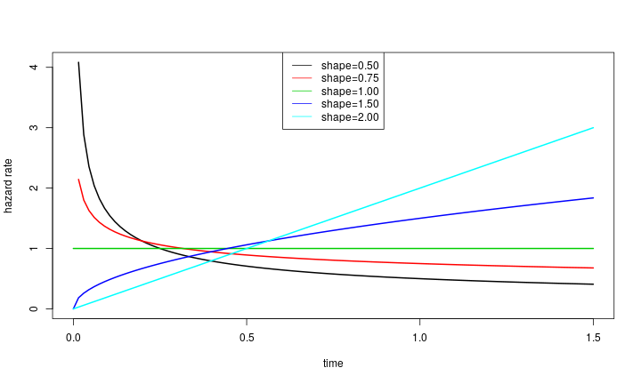

```r
kvals <- c(0.5, 0.75, 1, 1.5, 2)
xx <- seq(0, 1.5, length.out=101)
x <- sapply(kvals, function (k) dweibull(xx, shape=k)/pweibull(xx, shape=k, lower.tail=FALSE))
matplot(xx, x, type='l', lty=1, xlab='time', ylab='hazard rate', lwd=2)
legend("top", lty=1, col=1:5, legend=sprintf("shape=%0.2f", kvals))
```

# Fully parametric models

## Modeling

The idea: choose a (parametric) distribution for the time-until-event.

Some choices:

- Exponential (constant rate)
- Weibull
- Gompertz
- logNormal

Model:

- lifetimes are Weibull distributed
- mean lifetime depends on covariates

Model:

- lifetimes are Weibull distributed
- mean lifetime depends on covariates

$$\begin{aligned}
T_i &\sim \Weibull(\text{shape}=k, \text{mean}=\mu_i) \\
\mu_i &= \exp(y_i) \\
y_i &= \beta_0 + \sum_j \beta_j x_{ij}
\end{aligned}$$

Three ways to do parametric survival analysis:

- `survival::survreg` : maximum likelihood
- `brms::brm` : Baysian, with Stan
- MC Stan

## Maximum likelihood: survreg

```r
weifit <- survreg(Surv(time, status) ~ sex + ph.ecog + ph.karno,
                  data = lung, dist='weibull')
```

## Bayesian: brms

```r
lung$censored <- ifelse(lung$status == 1, 'right', 'none')

brmfit <- brm(time | cens(censored) ~ sex + ph.ecog + ph.karno,
              data=lung, family='weibull')
```

[output not shown]

```
 Family: weibull
  Links: mu = log; shape = identity
Formula: time | cens(censored) ~ sex + ph.ecog + ph.karno
   Data: lung (Number of observations: 226)
Samples: 4 chains, each with iter = 2000; warmup = 1000; thin = 1;
         total post-warmup samples = 4000

Population-Level Effects:
          Estimate Est.Error l-95% CI u-95% CI Rhat Bulk_ESS Tail_ESS
Intercept     6.61      0.67     5.36     7.99 1.00     2739     2666
sex           0.42      0.12     0.18     0.67 1.00     3502     2945
ph.ecog      -0.49      0.13    -0.74    -0.24 1.00     2531     2818
ph.karno     -0.01      0.01    -0.02     0.00 1.00     2644     2799

Family Specific Parameters:
      Estimate Est.Error l-95% CI u-95% CI Rhat Bulk_ESS Tail_ESS
shape     1.36      0.08     1.20     1.53 1.00     3708     3039

Samples were drawn using sampling(NUTS). For each parameter, Eff.Sample
is a crude measure of effective sample size, and Rhat is the potential
scale reduction factor on split chains (at convergence, Rhat = 1).
```

## Random effects, with brms

```r
brmfit2 <- brm(time | cens(censored) ~ sex + ph.ecog + ph.karno + (1|inst),
               data=lung, family='weibull')
summary(brmfit2)
```

```
##  Family: weibull
##   Links: mu = log; shape = identity
## Formula: time | cens(censored) ~ sex + ph.ecog + ph.karno + (1 | inst)
##    Data: lung (Number of observations: 226)
## Samples: 4 chains, each with iter = 2000; warmup = 1000; thin = 1;
##          total post-warmup samples = 4000
##
## Group-Level Effects:
## ~inst (Number of levels: 19)
##               Estimate Est.Error l-95% CI u-95% CI Rhat Bulk_ESS Tail_ESS
## sd(Intercept)     0.12      0.08     0.01     0.31 1.00     1639     1858
##
## Population-Level Effects:
##           Estimate Est.Error l-95% CI u-95% CI Rhat Bulk_ESS Tail_ESS
## Intercept     6.63      0.67     5.36     7.95 1.00     3514     3133
## sex           0.42      0.13     0.18     0.67 1.00     5396     2613
## ph.ecog      -0.50      0.13    -0.76    -0.25 1.00     3342     3061
## ph.karno     -0.01      0.01    -0.02     0.00 1.00     3398     3148
##
## Family Specific Parameters:
##       Estimate Est.Error l-95% CI u-95% CI Rhat Bulk_ESS Tail_ESS
## shape     1.37      0.09     1.20     1.54 1.00     4942     2869
##
## Samples were drawn using sampling(NUTS). For each parameter, Eff.Sample
## is a crude measure of effective sample size, and Rhat is the potential
## scale reduction factor on split chains (at convergence, Rhat = 1).
```

```r
ranef(brmfit2)
```

```
## $inst
## , , Intercept
##
##         Estimate Est.Error        Q2.5     Q97.5
## 1   -0.077081047 0.1121902 -0.34453070 0.1052658
## 2   -0.051925091 0.1448818 -0.40060675 0.1929411
## 3   -0.003140926 0.1052136 -0.22609347 0.2210849
## 4    0.017833583 0.1226034 -0.22299699 0.3069706
## 5   -0.038681462 0.1353150 -0.35932986 0.2186037
## 6   -0.042325779 0.1144701 -0.31423089 0.1645995
## 7    0.025663604 0.1249884 -0.21553215 0.3238278
## 10  -0.046230231 0.1427945 -0.37326527 0.2203388
## 11   0.039240593 0.1136011 -0.17209673 0.3056447
## 12  -0.053260802 0.1130651 -0.31811782 0.1354898
## 13   0.047404908 0.1136277 -0.15599395 0.3150589
## 15   0.007206870 0.1268800 -0.25446182 0.2833138
## 16   0.061820871 0.1195758 -0.13391314 0.3491895
## 21  -0.066473590 0.1286672 -0.37756584 0.1363838
## 22   0.083172155 0.1223941 -0.09947608 0.3754763
## 26   0.039314096 0.1300442 -0.19835246 0.3580281
## 32   0.007893967 0.1329952 -0.27541795 0.3088573
## 33   0.006010918 0.1419936 -0.30783839 0.3107077
## 100  0.014532219 0.1370704 -0.26147744 0.3371779
```

# Application

Fit (and select) a proportional hazards model to the `veteran` dataset. What are the most important predictors of survival?

```r
data(veteran)
## help(veteran)
```

```
Veterans' Administration Lung Cancer study

Description:

     Randomised trial of two treatment regimens for lung cancer.  This
     is a standard survival analysis data set.

Usage:

     veteran

Format:

       trt:       1=standard 2=test
       celltype:  1=squamous,  2=smallcell,  3=adeno,  4=large
       time:      survival time
       status:    censoring status
       karno:     Karnofsky performance score (100=good)
       diagtime:  months from diagnosis to randomisation
       age:       in years
       prior:     prior therapy 0=no, 10=yes
```

# Overview of brms

## Fitting models

```
brm(formula = z ~ x + y + (1 + y|f), data = xy,
    family = gaussian(link='identity'))
```

- `formula`: almost just like `lme4`
- `data`: must contain all the variables
- `family`: distribution of response
- `link`: connects mean to linear predictor

## Parameterization

There are several *classes* of parameter in a brms model:

- `b` : the *population-level* (or, *fixed*) effects
- `sd` : the standard deviations of *group-level* (or, *random*) effects
- family-specific parameters, like `sigma` for the Gaussian

Examples:

- `b_x` : the slope of `x` : `class="b", coef="x"`
- `sd_f` : the SD of effects for levels of `f` : `class="sd", coef="f"`

## Setting priors

Pass a *vector* of “priors”, specified by

```
    set_prior(prior, class="b", ...)
```

where `prior` is some valid Stan code.

```
brm(formula = z ~ x + y + (1 + y|f), data = xy,
    family = gaussian(link='identity'),
    prior=c(set_prior("normal(0, 5)", class="b"),
            set_prior("cauchy(0, 1)", class="sd", coef="f")))
```

## 1. Set up the formula

```r
xy <- data.frame(x = rnorm(100),
                 y = rexp(100),
                 f = sample(letters[1:3], 100, replace=TRUE))
xy$z <- xy$x + as.numeric(xy$f) * xy$y + rnorm(100, sd=0.1)
```

```r
the_formula <- brmsformula(z ~ x + y + (1 + y | f))
```

## 2. Choose priors

Default:

```r
get_prior(the_formula, data=xy)
```

```
##                  prior     class      coef group resp dpar nlpar bound
## 1                              b
## 2                              b         x
## 3                              b         y
## 4               lkj(1)       cor
## 5                            cor               f
## 6  student_t(3, 1, 10) Intercept
## 7  student_t(3, 0, 10)        sd
## 8                             sd               f
## 9                             sd Intercept     f
## 10                            sd         y     f
## 11 student_t(3, 0, 10)     sigma
```

Choose modifications:

```r
the_priors = c(set_prior("normal(0,5)", class = "b"),
               set_prior("cauchy(0,2)", class = "sd"))
```

## 3. Fit the model

```r
the_fit <- brm(the_formula, data=xy, family=gaussian(),
               prior=the_priors)
```

## 4. Check converence

```r
summary(the_fit)
```

```
##  Family: gaussian
##   Links: mu = identity; sigma = identity
## Formula: z ~ x + y + (1 + y | f)
##    Data: xy (Number of observations: 100)
## Samples: 4 chains, each with iter = 2000; warmup = 1000; thin = 1;
##          total post-warmup samples = 4000
##
## Group-Level Effects:
## ~f (Number of levels: 3)
##                  Estimate Est.Error l-95% CI u-95% CI Rhat Bulk_ESS Tail_ESS
## sd(Intercept)        0.07      0.19     0.00     0.43 1.00      978     1165
## sd(y)                1.44      0.66     0.59     3.11 1.01      803     1031
## cor(Intercept,y)    -0.12      0.56    -0.95     0.90 1.00     1051     1277
##
## Population-Level Effects:
##           Estimate Est.Error l-95% CI u-95% CI Rhat Bulk_ESS Tail_ESS
## Intercept    -0.02      0.10    -0.14     0.08 1.00     1842     1471
## x             1.00      0.01     0.98     1.01 1.00     2405     2051
## y             1.93      0.87     0.05     3.64 1.01      599      455
##
## Family Specific Parameters:
##       Estimate Est.Error l-95% CI u-95% CI Rhat Bulk_ESS Tail_ESS
## sigma     0.09      0.01     0.08     0.10 1.00     2735     2410
##
## Samples were drawn using sampling(NUTS). For each parameter, Eff.Sample
## is a crude measure of effective sample size, and Rhat is the potential
## scale reduction factor on split chains (at convergence, Rhat = 1).
```

Or…

```
launch_shinystan(the_fit)
```

## 4. Look at results

Summaries of, or samples from, the posteriors of:

- `fixef( )`: “fixed” effects
- `ranef( )`: “random” effects
- `fitted( )`: *mean* of responses
- `predict( )`: actual responses
- `hypothesis( )`: functions of various parameters (e.g., difference between two classes)
- `marginal_effects( )`: effect of one predictor conditioned on values of others

# Review

Nonparametric:

- simple
- does not depend on model fit

Parametric:

- makes more sense: real hazard rates are not piecewise constant
- better power, *if* the model fits
- better extrapolation (but beware!)
- can simulate

## The Kaplan-Meier curve, by hand:

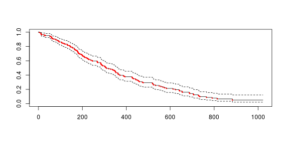

```r
f1 <- survfit(Surv(time, status) ~ 1, data = lung)

y <- data.frame(time=sort(unique(lung$time[lung$status == 2])))
y$k <- sapply(y$time, function (t) sum(lung$status == 2 & lung$time == t))
y$n <- sapply(y$time, function (t) sum(lung$time > t | (lung$time == t & lung$status == 2)))
y$p <- cumprod(1 - y$k/y$n)

plot(f1)
points(p ~ time, data=y, col='red', pch=20, cex=0.5)
```